# Serial reversal learning in nectar-feeding bats

Shambhavi Chidambaram<sup>1,2</sup>, Sabine Wintergerst<sup>3</sup>, Alex Kacelnik<sup>4</sup>, Vladislav Nachev<sup>1,5</sup>, York Winter<sup>1,2*</sup>,

<sup>1</sup> Institute of Biology, Humboldt University, Berlin, Germany

<sup>2</sup> Berlin School of Mind and Brain, Humboldt University, Berlin, Germany

<sup>3</sup> Fairchild Tropical Botanic Garden, Miami, USA

<sup>4</sup> Department of Biology and Pembroke College, University of Oxford, UK

<sup>5</sup> Berlin Institute of Health (BIH) at Charité - BIH QUEST Center for Responsible Research, Berlin, Germany (present affiliation)

***For correspondence:** york.winter@hu-berlin.de

**Present Address:** Institute of Biology, Humboldt University, Philippstr. 13, 10115 Berlin, Germany

# Abstract

We explored the behavioural flexibility of Commissaris’s long-tongued bats through a spatial serial reversal foraging task. Bats kept in captivity for short periods were trained to obtain nectar rewards from two artificial flowers . At any given time only one of the flowers provided rewards, but this reversed in successive blocks of 50 flower visits. All bats detected and responded to reversals by making most of their visits to the currently active flower. As the bats experienced repeated reversals, their preference re-adjusted faster, and the level of commitment to the active flower at the end of each 50-visit block decreased. Although the flower state reversals were theoretically predictable, we did not detect anticipatory behaviour, that is, frequency of visits to the alternative flower did not increase within each block as the programmed reversal approached. The net balance of these changes was a progressive improvement in performance in terms of the total proportion of visits allocated to the active flower. The results are compatible with, but do not depend on, the bats displaying an ability to ’learn to learn’and show that the dynamics of allocation of effort between food sources can change flexibly according to circumstances.

# Introduction

Many animals face frequent and unpredictable changes in the relative profitability of food sources. This is the case for animals that forage for nectar and/or pollen in flowering plants. Though flowers are stationary, changes in their profitability occur at many time scales. Many plants bloom seasonally, and single flowers on plants themselves wither and die every day or every few days. Furthermore, they are depleted and replenished at various timescales by the interplay of foragers and nectar production, altering their profitability as food resources with the passage of time.

Behavioural flexibility helps to cope with such changes. The word ‘flexibility’ has been used to mean many different things in the animal behaviour literature (often inconsistently – for a discussion see (Audet and Lefebvre 2017)), and one of its manifestations relates to the concept of elasticity: behavioural patterns that can be repeatedly and readily reversed (Bond, Kamil, and Balda 2007). An experimental protocol that has been widely used to test for and demonstrate this sort of flexibility is reversal learning (Izquierdo et al. 2017).

In a reversal learning task, an animal first learns about multiple stimulus-reward pairings, such as two or more spatial locations that can be visited to potentially obtain rewards. In the initial phase, subjects typically bias their behaviour towards the richer location. When contingencies are stable and/or only one of the locations offers rewards, the reward-maximizing strategy is to allocate all behaviour to that one. However, if and when the contingencies in the available sources change, behavioural allocation is expected to, and typically does, change. The temporal course of such reversals is an informative index of the difference in flexibility between species (Bond, Kamil, and Balda 2007), between sexes (Lois-Milevicich et al. 2021), between temporal or experienced contingencies (A. P. Smith, Zentall, and Kacelnik 2018), (Santos, Vasconcelos, and Machado 2021) and other cases. Here we use a reversal protocol to explore flexibility in learning dynamics and how it affects the foraging efficiency of nectar-feeding bats.

In situations where there are two sources, of which at any given time only one is active, but which one it is switches frequently, foraging yield is positively related to allocation to the currently active source and to the speed of detection of reversals. in these scenarios there is a trade-off between these two factors, because greater commitment to one source reduces the information available about the state of the other. When reversals are between two continuous reinforcement reward schedules (i.e., when any active source yields food on every visit), the theoretical strategy “Win-Stay, Lose-Shift” (WSLS) is almost perfectly maximizing, since it takes only one unrewarded visit to detect each reversal (minor deviations are not of interest here). However, WSLS has not been found to accurately describe the behaviour of experimental animals (A. P. Smith, Zentall, and Kacelnik 2018), (Santos, Vasconcelos, and Machado 2021). Instead, typically, behaviour is better described by combined sensitivity to schedule properties that, although programmed deterministically, are evidently not perceived as such by the subjects. In some cases, the mechanism by which the subject allocates choices is expressed in continuous (rather than discrete) changes in behaviour. For instance, in the mid-session reversal protocol, reversals are programmed to occur after a fixed number of responses, which usually corresponds with a somewhat predictable point in time. Using pigeons as subjects, A. P. Smith, Zentall, and Kacelnik (2018) found that as a reversal approached, in trials where subjects faced only one option rather than a binary choice, pigeons showed a smoothly increasing latency to respond to the currently rewarding option, and a decreasing latency to respond to the soon-to-be-rewarding option. In intermingled choice trials, there were both anticipatory and perseverative responses to the currently non-rewarding option. Thus, the independent smooth variation in latencies in single option trials correlated, probably causally, to the gradual and probabilistic distribution of choices in two-option trials, a regularity that describes well behaviour in other protocols (Kacelnik et al. 2011).

In serial reversal learning procedures, where reward contingencies reverse repeatedly, subjects can use their experience to adjust the dynamics of behaviour allocation so as to improve reward yield. In other words, subjects could show second order learning, or learning to learn, similar to observations in ‘learning set’ protocols (Harlow 1949). This could involve learning that the sudden absence of reward signals reliably that reward contingencies have reversed.

We carried out a serial reversal learning task with Commissaris’s long-tongued bats, (*Glossophaga commissarisi*), which primarily feed on flower nectar (Tschapka 2004). They may often experience reversal situations in their natural environment, because a flower may remain rewarding for multiple visits before it is depleted by self or a competitor or withers and dies. When a given flower becomes inactive, the memory of previously rewarding flowers that may have replenished is likely to drive visits to nearby alternatives. In our experiment, bats were offered two potentially rewarding options, identified by their spatial location. Glossophagine bats have well-developed spatial memory (Stich 2004 - chapter 2); (Stich 2004 - chapter 3); (Thiele and Winter 2005); (Winter and Stich 2005) so no other cue was necessary. At the start of each night, one of the options was active, yielding nectar every time it was visited (the ‘S+’ option), while the alternative was inactive (the ‘S-’ option). After a fixed number of visits, the reward contingencies reversed without any additional cue: the rewarding option became inactive (S-) and the previously unrewarding option became active (S+). This reversal happened five times in a night.

In the wild, when new flowers become available, bats can quickly learn the locations associated with high reward, a form of first-order learning ((Stich 2004 - chapter 2), (Stich 2004 - chapter 3); (Winter, Merten, and Kleindienst 2005); (Tölch and Winter 2007); (Nachev and Winter 2012); (Nachev et al. 2017) – this research also showed that bats learn a change in spatial location much faster than when flowers differ in echo-acoustic properties). Frequent changes in flower properties may involve second order learning, in which bats’ biasing towards present relative profitability reflects not just present reward but also the dynamics of previously experienced changes. The aim of our present experiment was to test if bats show flexibility in their adjustment to repeated reversal of contingencies, so that experience with changes translated into improvements in foraging efficiency.  
Since in our protocol there is a simple, near-optimal strategy, in the form of win-stay lose-shift, we were also interested in finding out whether the bats progressively approached this strategy by learning to reallocate behaviour more abruptly after just one unrewarded visit.

# Methods

## Study site and subjects

The experiment took place at the Organisation for Tropical Studies (O.T.S/O.E.T) La Selva Biological Field Station, Province Heredia, Costa Rica in June-July 2017. *Glossophaga commissarisi* bats were captured and retained in a flight cage through the experiment. The bats were attracted to a particular location in the forest using chicken-feeders filled with sugar-water (see *Reward*) as bait. The feeders had cotton swabs soaked in dimethyl disulphide on them, a chemical odour attractant produced by many bat-pollinated flowers (Helversen, Winkler, and Bestmann 2000) and then caught in mist-nets. The bats were sexed on capture and housed in two outdoor, meshed flight-cages (4 x 6 m) under ambient light conditions. All individuals were weighed and marked with radio frequency identification (RFID) tags placed as collars around their necks.

A total of 16 bats participated in the main experiment and the first stage of the experiment began on the night the bats entered the cages. A group of four experimental bats of the same sex were placed in a flight cage together. Two such groups were run in parallel, one in each flight-cage so the data were collected simultaneously. At the end of the experiment, the RFID collars were removed, and the bats were released back into the wild. All the data collection was completely automatized. Two of the bats did not drink a sufficient amount of sugar-water to meet minimum energy requirements. These two bats were released before the end of the experiment and not replaced, and data from these two individuals were not analyzed. Thus, 14 bats (7 males and 7 females) completed the experiment. Permission for this research was granted by Sistema Nacional de Areas de Conservación (SINAC) at the Ministerio de Ambiente y Energía (MINAE), Costa Rica.

## Experimental Setup

### Reward

The reward received by the bats during the experiment was also their main source of food. The reward was a 17% by weight solution of sugar dissolved in water, hereafter referred to as ‘nectar.’ The sugar consisted of a 1:1:1 mass-mixture of sucrose, fructose and glucose. The nectar was thus similar in composition and concentration to the nectar produced by wild chiropterophilous plants (Baker, Baker, and Hodges 1998). Every night, the bats were also given *ad-libitum* access to 10 mL of supplemental food: 3.5 g of hummingbird food (NektarPlus, Nekton, Germany) and 3.5 g of milk powder (Nido 1+, Nestle, Switzerland) in 10 mL of water. The bats in each cage were also given a small bowl of locally-sourced bee pollen.

### Flower and pump setup

Each flight cage had a square frame in the center (2 × 2 m), fixed 1.5 m above the ground. Eight reward-dispensing devices – hereafter referred to as ‘flowers’ – were fixed two on each side of the square (Figure 1) with a distance of 40 cm between adjacent flowers. At this separation, bats can fully discriminate neighbouring spatial locations (Thiele and Winter 2005); (Winter, Merten, and Kleindienst 2005). Each flower had the following parts: a circular RFID antenna mounted at the end of a plastic cylinder that constituted the artificial flower; an infrared photo gate; and an electronic pinch valve through which a silicon tube was placed and fixed to the base of the flower.

A stepper-motor syringe pump was placed in the center of the square in each cage with a 25 mL Hamilton glass syringe (Sigma Aldrich, Germany). All bats received the same volume of reward on each visit: 40 $\mu$L of nectar. The syringe was connected to the tubing system of the flowers through five pinch valves (Nachev and Winter 2012). The pinch valves controlled the flow of liquid from the pump to the flower system and from a reservoir of liquid to the pump. The reservoir (500 mL bottle, Roth, Germany) was filled with fresh nectar every day.

Every day, an automated routine was started at around 10:00. The system was emptied of remaining nectar and rinsed with plain water. The system was then filled with water and kept this way until 15:00, when it was filled with fresh nectar. Twice a week, the system was filled with 70% ethanol for an hour to prevent microbial growth, then rinsed with water.

When a tagged bat approached a flower, its individual number was read. If the bat then poked its nose into one of its assigned flowers and interrupted the light beam, this was recorded, and if the flower was currently active, a reward was released. The flowers were programmed such that each bat could trigger rewards at only two unique flowers out of the array of eight. Upon a nose poke, the pinch valve opened, and the pump dispensed nectar to the base of the flower. The bat could hover in front of the flower and lick up the nectar. The flowers and the pump were connected to a Windows PC, which ran the experimental programs, collected the data and also ran the routine program used to automatically flush, clean and fill the pump and tubing system (PhenoSoft Control, PhenoSys, Germany).

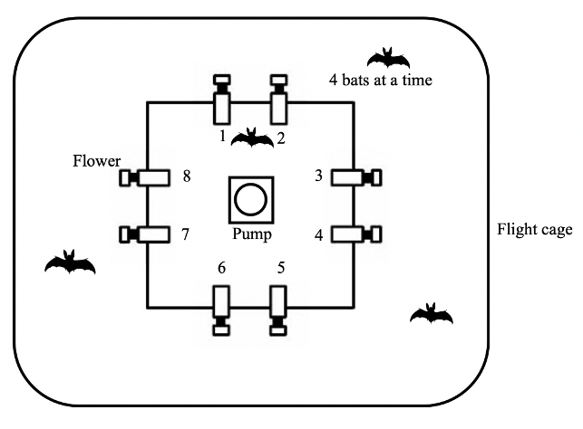

Figure 1: Schematic of the cage and flower set-up (not drawn to scale). Dimensions of the flight cage were 4x6 m. The square holding the artificial flowers measured 2x2 m and was 1.5 m above ground. Neighbouring flowers were 40 cm apart.

## Experimental procedure

Out of the array of eight flowers, each bat was assigned two adjacent flowers on the same side of the square frame, programmed to reward only one of the bats in the cage. After the system was filled with fresh nectar at 1500 h, the program was launched at approximately 1700 h and left running for data-collection till the next morning. Thus, the bats could begin visiting the baited flowers whenever they chose, which was at nightfall, at approximately 1800 h every night. During the main experiment, each bat could make a maximum of 300 rewarded visits a night, after which both flowers would cease to offer rewards. However, most bats had consumed enough nectar to be satiated before reaching this limit, and there were very few visits after the flowers ceased to offer rewards.

During the course of the night, when the syringe had been emptied, the pump re-filled automatically. This happened only once every night and it took 4.5 minutes (SD = ±0.18) for the cage 1 pump, and 2.4 minutes (SD = ±0.04) for the cage 2 pump.

About 1 % (SD = ±0.74) of all visits made by the bats were wrongly unrewarded, meaning that a bat did not receive a reward even when the visit was made to a flower that was supposed to be rewarding at the time. This happened either during the pump refill times or when the pump was moving to reward a visit made by another bat that happened almost at the same time. Such events did not count towards the total of 300.

## Experimental design

The experiment proceeded through the following stages.

### Training

On the night the naïve bats were captured and placed into the flight cages, they could receive a reward from any of the flowers whenever they visited them throughout the night. To facilitate a fast learning of our artificial flowers as locations of reward, a small cotton pad soaked in dimethyl disulphide was placed on each flower to encourage the bats to explore the flower heads for nectar food, interrupt the photo gate, and trigger a nectar reward. By the end of the night, all the bats had found the flowers and learned to trigger rewards. The next stage of training involved assigning each bat to two of the eight flowers in the array. For an individual animal, only the two flowers assigned to it would elicit rewards from this stage of training until the end of the experiment. This stage was similar to the previous one, except that the bats could only collect nectar from their assigned flowers. The chemical attractant was not used. To ensure that each bat was familiar with both its assigned flowers, we added a final stage of training: forced alternation. The bats received a reward at one of the two flowers for one trial, and then could only receive reward at the other flower for the next trial. If the bat repeatedly visited the same flower, the other flower would remain rewarding until it was visited.

### Serial Reversal Learning Task

In the serial reversal learning stage, for any given bat at any given time one of its two flowers gave a 40 $\mu$L nectar reward, and the other was unrewarding. After a bat had made 50 visits in total to its assigned two flowers, a reversal occurred: the previously rewarding flower became non-rewarding and *vice versa*. Only visits to the two flowers assigned to each bat counted towards its visit tally, and the distribution of visits between these two flowers did not have any effect. Each set of 50 visits was termed a ‘block.’ Each bat had six blocks and five reversals per night, unless it ceased visiting earlier. This was repeated for three consecutive nights, and the same flower started the sequence every night. However, since bats already during the first night seemed to have reached their asymptote of quickly adjusting their choices after a reversal had occurred, and, furthermore, data from 2nd and 3rd nights were affected by carry-over memory, possibly including the extinction at the end of the previous day, for this study we focus on the analysis of the five reversals experienced the first night.

## Data analysis

All the statistical models were fitted in a Bayesian framework using Hamiltonian Monte Carlo in the R package `brms` (Bürkner 2017) which is a front-end for `rstan` (Carpenter et al. 2017). Generalized linear mixed models were used for the analyses (see *Supplementary Information* for the technical details of the model fitting). Unless mentioned otherwise, we report here the mean as a measure of central tendency and the 89% quantile-based credible intervals for the intercept and slope coefficients (89% boundaries are the default for reporting credible intervals – McElreath (2020)). To aid in the interpretation of the model parameters we also present plots of the conditional effects of some of the predictor variables.

Visual inspection of the whole data set showed a qualitative difference between the first and later nights, implying that any second-order learning effect already reached asymptotic stability by the 5th reversal at the end of the first night. To avoid masking first-night acquisition effects by swamping them with post asymptotic (overtraining) data we focus on the first night but present the full data set in the supplementary material.

The first reversal was experienced at the end of the first block of the first night, namely by the 51st flower visit for each bat. Hence this is where we started the analysis to seek for evidence of 2nd order learning. We used the proportion of visits to each of the two flowers in each 10-visit bin as response variable and fitted a generalized linear mixed-model (GLMM) using bin and reversal number and their interaction, as explanatory variables. The proportion of visits to the rewarding flower was given by the number of visits to the S+ divided by 10, which was the total of visits made to both flowers in each bin. This was denoted as the Prop<sub>rew</sub>.

Confidence intervals were calculated by non-parametric bootstrapping without assuming a normal distribution of the data, using the `Hmisc` package (Jr and functions) 2023).

## Data availability

# Results

Overall, 79.4% [95% CI 78.1, 80.7] of the bats’ visits were to the rewarding flower. Figure 2a shows the temporal adjustment of visit allocations between the assigned flowers, highlighting both the effect of experience within a block and between blocks (i.e, reversals). Within each block allocation to the rewarding flower increased with successive bins, progressing towards an asymptotic proportion. After each reversal, persistence to the previously rewarding source was brief – though longer than the single response expected from win-stay lose-shift - as the bats’ responses quickly evolved towards a new asymptotic distribution with a bias towards the current source of nectar.

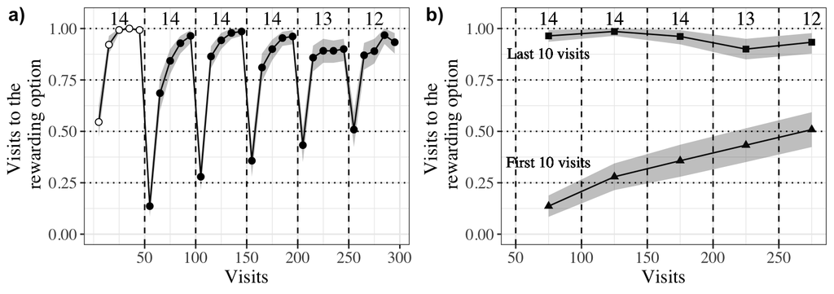

Figure 2: Visits to the rewarding one of two options. Shading shows 95% confidence intervals, and numbers indicate the total number of bats that participated in a block. Data are average proportions for bins of ten visits averaged over all the individuals that made visits in each bin. Vertical dashed lines show reversals a) Data indicated by white circles in the first block were before the bats had experienced any reversals; black circles after the experience of a reversal b) Data indicated by triangles are proportions of rewarded visits in the first bin of 10 visits in a block; by squares, in the last bin of 10 visits in a block.

The most salient signal for 2nd order behavioural change was the decline in perseverative visitation to the previously-rewarding option after consecutive reversals, as is apparent in Figure 2. The proportion of visits to the presently rewarding flower in the first bin of 10 visits after a reversal increased more than in any other bin as the bats accumulated experience. This is observable in the raw data (Figure 2b, 3), and held up by the statistical analysis (Figure 4).

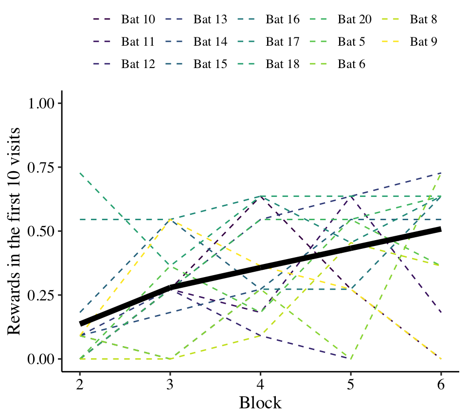

Figure 3: Proportion of visits to the rewarding option out of the first 10 visits after each reversal. Thin lines are individual data, and the thick line is the average proportion of rewarded visits over all bats.

Statistically, Prop<sub>rew</sub> in the first bin of each block increased significantly as the bats experienced successive reversals. This reversal-dependent or second order effect was present in the second bin of 10 visits (visits 11 - 20) as well, but by the third bin the reversal effect was not statistically detectable (Figure 4). The mechanism for the acceleration of switching could depend on the bats forming an expectation that things change after about 50 visits, leading to an increase in the proportion of win-shift (“proactive sampling”) responses towards the end of each block. An alternative, not mutually exclusive, mechanism could be an increase in lose-shift probability, which would be evidenced by the dynamics at the beginning of each block, after reversals. There is no strong evidence of the former (but see the trend to lower asymptotes in Figure 2) but there is reliable statistical evidence for the latter (see Figure 4). On balance, one may expect both factors to play some role.

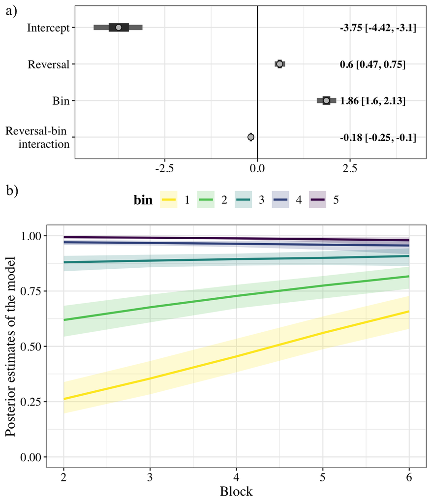

Figure 4: a) Forest plot of the regression coefficients from the model of the effect of reversal and 10-visit bin on the visits to the rewarding flower. Data are means and their 50% and 89% credible intervals of the posterior distributions of the slope coefficients, with their values given on the right b) Conditional effects plot from the model of the effect of reversal and 10-visit bin on the visits to the rewarding flower showing the effect of reversal and bin, sampling from the posterior distribution.

When the bats had their very first experience of a reversal, the proportion of rewarded visits dropped to the lowest level of the whole experiment. So, we asked whether the first reversal just by itself was responsible for the significance of the factor *number of reversal* on Prop<sub>rew</sub> in our statistical model of the data set. We found that this was not the case. To investigate this, we removed these data and repeated the analysis. We found that the effect of the reversals on the Prop<sub>rew</sub> persisted, even without the effect of the first reversal (see *Supplementary Information*).

# Discussion

We studied temporarily captive wild nectar-feeding bats in a spatial serial reversal learning task with two food sources that repeatedly alternated their rewarding properties, seeking evidence for behavioural flexibility in the mechanisms by which bats adjust to dynamically changing foraging environments. From a functional perspective, we sought to characterize the consequences of such adjustments in terms of payoffs. We found that as bats experienced more reversals, they decreased their asymptotic commitment to the presently better source and reduced the number of perseverative failures after each reversal. On balance, these two effects resulted in an increase in the total proportion of visits made to active flowers, leading to better yields.

In this protocol, the theoretical Win-Stay, Lose-Shift strategy would yield virtually maximal payoffs (losing only one reward per reversal). The bats did not follow WSLS, but they did increase the proportion of shifts after a loss, this reducing the deviation from it. This “speed of switching” increased within five experiences of reward reversal, in their first experimental night. Further experience, in two follow-up nights with 5 reversals each, did not yield further detectable changes (Supplementary Information), indicating a protocol-dependent ceiling in performance.

The probability of returning after a reward (win-stay) was high from the start, and an increase as a function of reversals would have been harder to detect precisely because it was already very high from the first block onwards. It would be misleading to label deviations from WSLS as anticipatory or perseverative ‘errors’: Although in the experimental protocol contingencies changed precisely every 50 visits, the bats had no reason to be perfectly tuned to this. Changes in natural flowers are likely to be temporally noisy, and a probabilistic approximation to the WSLS policy may provide a good balance between sampling and exploitation.

We were interested in demonstrating a learning property: the ability to adjust to temporal properties of food sources. The mechanisms revealed in our experiments are bound to be present in nature. However, to form a picture of the ecological relevance of our results, it is pertinent to highlight some differences between our protocol and natural situations. First, our bats were not deprived, as we used a large reward size (40 $\mu$L) and supplementary food was always available. Levels of deprivation are bound to vary widely in the wild, and this may have complex effects on learning, decision making, and the balance between exploration and exploitation. Second, we offered two flowers with deterministic properties. In nature, the set of potential food sources is open and -from a forager’s perspective- vary stochastically due to fluctuations imposed among other factors by competition. These caveats are ubiquitous: laboratory experiments expose behavioural mechanisms, but do not substitute empirical research in the ecological circumstances to which behaviour is adapted.

That said, it is also noteworthy that though most flowers in nature are emptied in a single visit, there are certain plants such as species of *Agave* or *Vriesea*, that may hold large amounts of nectar. If undetected for a long time such flowers require multiple hovering visits to deplete – in other words, they are “jackpot” rewards. Nevertheless, such flowers may also be depleted suddenly due to the presence of competitors for the nectar. Thus, the ability to swiftly inhibit visiting a flower that had been rewarding for multiple visits is likely bats’ natural foraging ecology as nectar-feeding animals.

Bat behaviour and learning processes are surely adapted to fit the complexity of their environment and may reflect priors and learning processes that are effective in such scenarios. This general observation does not question the reliability of laboratory findings but is a reminder of the caution that must be shown in extrapolating to natural circumstances, especially when aspects of behaviour are, as sometimes happens, labelled as being ‘errors’ or being ‘suboptimal.’

After the bats experienced no reward at a hitherto-rewarding option for the first time, the proportion of rewarded visits decreased, and never again became as high as it was in the first block. Bats, like most vertebrate foragers, are known to adjust their choice behaviour between different available options according to their history of reinforcement at those options (Nachev and Winter 2012). If it is solely reinforcement history that dictates choice behaviour, regardless of temporal structure and dynamics, then as experience of reinforcement accumulates at both flowers over the course of a night, it should become progressively more difficult to discriminate which flower has a richer history. In this case, one would expect that the bats’ behaviour would approach random choice as the night goes on, i.e. Prop<sub>rew</sub> would approach 0.5 and there would be slower modification of behavioural allocation. Even if the animals rely only a part of their history of reinforcement at an option, and not the whole history, one would expect to see a slower switch to the rewarding option after a reversal, and then an increase in rewarded visits. This is the opposite of what was seen: with more reversal experience the bats switched to the newly rewarding option after increasingly fewer choices. However, behavioural allocation at the end of each block did show a weak trend to progressively become less extreme as reversal experience accumulated, and the weight of cumulative past reinforcement may be a contributing factor in this.

While it is clear, therefore, that the bats’ choice behaviour was not dictated by the cumulative reinforcement history at the two options, the readiness to switch to the rewarding option reached a maximum by the end of the first night, after five reversals (see Supplementary Material). It is interesting that while appropriate re-allocation became swifter after successive reversals, the theoretical reward-maximizing strategy (Lose-Shift), which would incur only one unrewarded visit per block, was never reached, and both speed of switching and asymptotic commitment to the better option seemed to reach a limit towards the end of the first night. In fact, total commitment to the best option in a set is not to be expected if a forager is adapted to track changes in its environment, appoint already made in the early foraging literature (e.g., (J. N. M. Smith and Sweatman 1974)).

What performance on the serial reversal task says about the cognitive mechanisms at work is not completely settled. Cognitive flexibility relies on processes in the brain that permit adaptive change in behaviour in response to changes in the internal or external environment, whereas behavioural flexibility is the modifiability of learned behaviour (Dhawan, Tait, and Brown 2019). Cognitive flexibility cannot be directly observed; it is inferred to have occurred through behavioural flexibility (Tait et al. 2018), and the reversal learning task has been variously considered as a test of cognitive flexibility (Izquierdo et al. 2017) and behavioural flexibility (Dhawan, Tait, and Brown 2019).

Behavioural flexibility has been found in most species tested in reversal learning tasks regardless of whether they depend on flowers or need both spatial memory and some form of renewal of information or ‘book-keeping’ to perform adaptively. This includes our own study species (Thiele 2006), bumblebees (Strang and Sherry 2014; Chittka 1998), honeybees (Mota and Giurfa 2010; Menzel 1969), rats [Mackintosh (1965); (Van Golf Racht-Delatour and El Massioui 1999; Dhawan, Tait, and Brown 2019), pigeons (Williams 1967), rabbits (Orona et al. 1982), corvids (Bond, Kamil, and Balda 2007), pigeons (Diekamp, Prior, and Güntürkün 1999), marmosets (Clarke, Robbins, and Roberts 2008) and even human children (Eimas 1966). It is also present in species adapted to different spatial demands, such as hoarding species of passerines such as black-capped chickadees (Hampton, Shettleworth, and westwood 1998), Clark’s nutcrackers (Lewis and Kamil 2006) and high elevation mountain chickadees (Croston et al. 2017) and in brood parasitic birds that must keep some form of ‘book-keeping’ regarding the state and availability of potential target host nests (Guigueno et al. 2014; Guigueno, MacDougall-Shackleton, and Sherry 2016; Lois-Milevicich et al. 2021). The processes and parameters of first- and second-order learning about location and state of reward sources, and other qualitative and quantitative details must adaptively reflect the biology of each species, but a common picture emerges, in which animals display remarkable abilities to pick up the relevant environmental affordances at various temporal and spatial scales.

# Acknowledgements

# Author contributions

**SC**: formal analysis, data curation, writing – original draft, writing – review and editing. **SW**: conceptualization, experimental methodology, data collection. **AK**: formal analysis, writing – review and editing, supervision. **VN**: formal analysis, data curation, writing – review and editing, supervision. **YW**: conceptualization, experimental methodology, resources, formal analysis, writing – review and editing, supervision.

# Funding

This work was funded partly by a scholarship from the Deutscher Akademischer Austauschdienst (DAAD) to SC.

Support was provided through DFG Deutsche Forschungsgemeinschaft (DFG, German Research Foundation), SFB 1315, project-ID 327654276, and EXC 257 NeuroCure, project-ID 441 39052203

AK is grateful to the Deutsche Forschungsgemeinschaft (DFG, German Research Foundation) for support under Germany’s Excellence Strategy – EXC 2002/1 “Science of Intelligence” – project number 390523135.

# Availability of data and code

# Declarations

## Competing interests

None

# Supplementary Material

## Visits and approaches to the unassigned flowers

Only two out of the array of eight flowers were assigned uniquely to each bat but all the flowers were accessible to all the animals. The number of attempts to get a reward from all the flowers, both assigned and not assigned is shown in Figure 5.

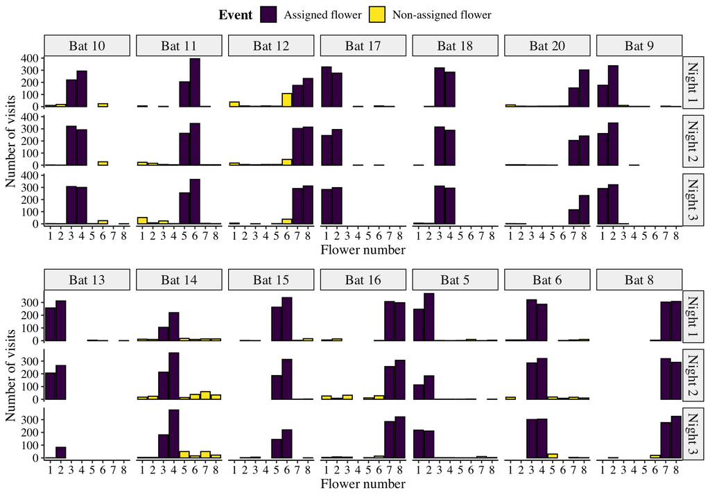

Figure 5: Visits made by the bats to all the flowers, including the ones that were not assigned to them. Purple bars are nose-pokes at the assigned flowers, where the bats attempted to get a reward by breaking the light-barrier. Yellow bars are nose-pokes at the non-assigned flowers.

The number of approaches or attempts to get a reward at the non-assigned flowers was a small proportion of the overall number of approaches and reward-attempts at the flowers, less than 10% every night on average as Figure 6 shows.

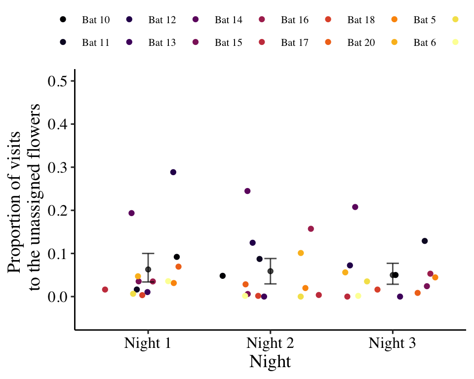

Figure 6: Proportion of visits or approaches to the un-assigned flowers out of the total number of visits or approaches to flowers. Coloured points are data from individual bats. Black points are the mean proportion per night and the error bars are 89% CIs.

## Details of the statistical analyses

Weakly informative priors were used for the GLMMs in `brms`. All the models were estimated using 4 chains with a thinning interval of 3, with 1500 warm-up samples and 3000 post-warm-up samples for all the models except the one fitted to the data from the second and third nights, which had 1000 warm-up samples and 3000 post-warm-up samples. The response variable was the proportion of visits to the rewarding option, and a Bernoulli likelihood function was used. For the model of the first experimental night, the reversal number, 10-visit bin within each block, and their interaction were the fixed effects. Slopes and intercepts were allowed to vary for each animal. For the model of the second and third experimental nights, the experimental night, reversal number, 10-visit bin within each block, night-reversal interaction and reversal-bin interaction were the fixed effects. Slopes and intercepts were allowed to vary for each animal.

Visual inspection of the trace plots, the effective sample size, the Gelman-Rubin convergence diagnostic ($\hat R$) and the calculation of posterior predictions for the same clusters were all used to assess the fit of the models. In all the models the $\hat R$ was equal to 1 for all the chains.

## The effect of reversal is not driven solely by the effect of the first reversal on the first night

The effect of reversal on the visits to the rewarding flower persisted even when the entire data of from the first block after the first reversal were removed from the analysis, and a similar GLMM was fit Figure 7.

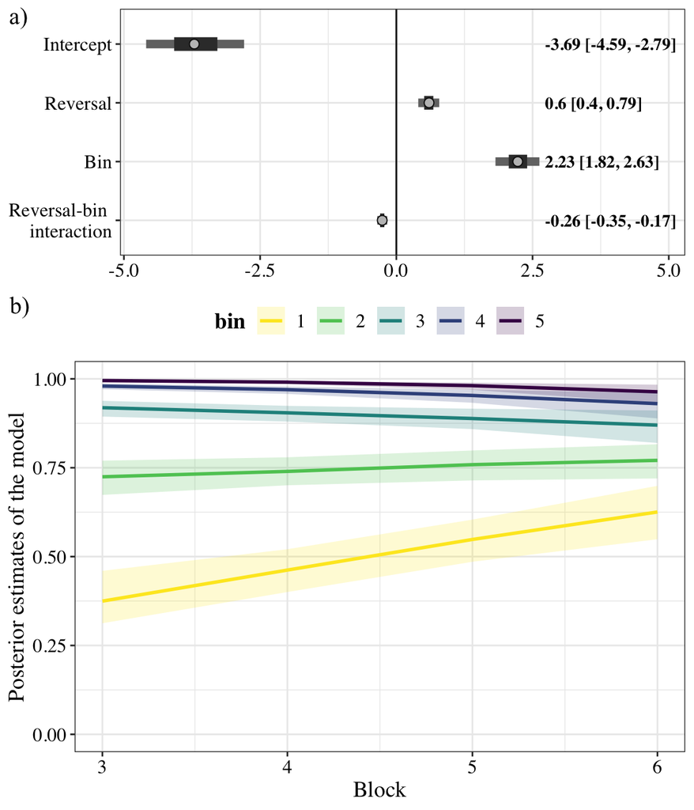

Figure 7: a) Forest plot of the regression coefficients from the model of the effect of reversal and 10-visit bin on the visits to the rewarding flower, excluding the first reversal. Circles represent the means of the posterior distributions of the slope coefficients, thick horizontal lines represent 50% credible intervals, and thin horizontal lines 89% credible intervals. The numbers in bold are the means of the posterior distributions and 89% credible intervals b) Conditional effects plot from the model of the effect of reversal and 10-visit bin on the visits to the rewarding flower - excluding the first reversal - showing the two-way interaction between reversal and bin, sampling from the posterior distribution.

## In the later stages of the experiment the proportion of rewarded visits did not increase due to reversal experience

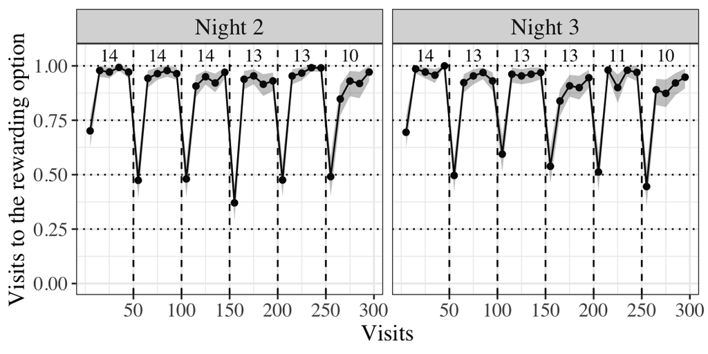

Figure 8: Visits to the rewarding one of two options over second and third experimental nights. Data are average proportions for bins of ten visits averaged over all the individuals that made visits in each bin. Numbers indicate the bats that participated in a block. Shading shows 95% confidence intervals. Dashed lines show reversals

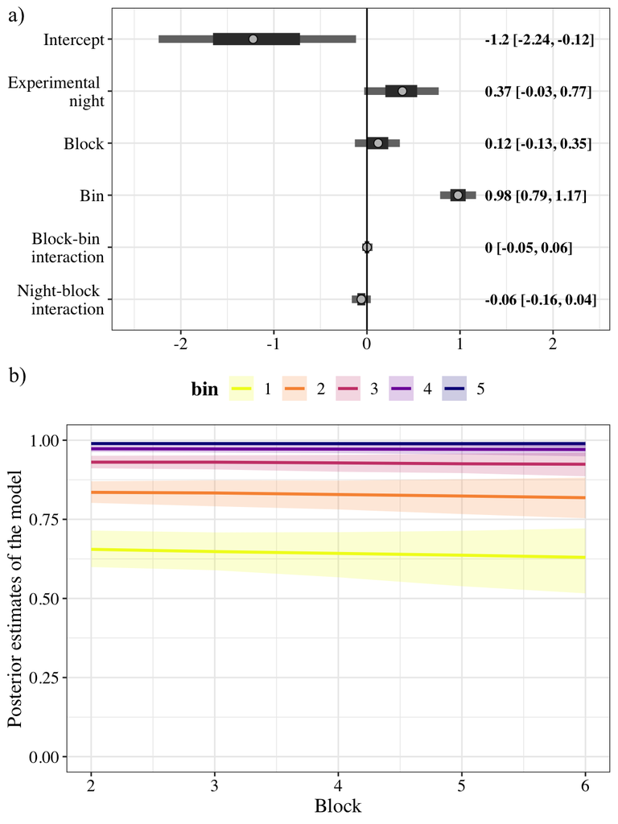

Figure 9: a) Forest plot of the regression coefficients from a model of the effect of experimental night, reversal and 10-visit bin on the visits to the rewarding flower, excluding the first night. Circles represent the means of the posterior distributions of the slope coefficients, thick horizontal lines represent 50% credible intervals, and thin horizontal lines 89% credible intervals. The numbers in bold are the means of the posterior distributions and 89% credible intervals b) Conditional effects plot from the model of the effect of experimental night, reversal and 10-visit bin on the visits to the rewarding flower - excluding the first night - showing the two-way interaction between reversal and bin, sampling from the posterior distribution.

# References

Audet, Jean-Nicolas, and Louis Lefebvre. 2017. “What’s Flexible in Behavioral Flexibility?” *Behavioral Ecology* 28 (4): 943–47. https://doi.org/10.1093/beheco/arx007.

Baker, Herbert G., Irene Baker, and Scott A. Hodges. 1998. “Sugar Composition of Nectars and Fruits Consumed by Birds and Bats in the Tropics and Subtropics.” *Biotropica* 30 (4): 559–86. https://doi.org/https://doi.org/10.1111/j.1744-7429.1998.tb00097.x.

Bond, Alan B., Alan C. Kamil, and Russell P. Balda. 2007. “Serial Reversal Learning and the Evolution of Behavioral Flexibility in Three Species of North American Corvids (*Gymnorhinus Cyanocephalus, Nucifraga Columbiana, Aphelocoma Californica*).” *Journal of Comparative Psychology* 121 (4): 372–79. https://doi.org/10.1037/0735-7036.121.4.372.

Bürkner, Paul-Christian. 2017. “**Brms** : An *r* Package for Bayesian Multilevel Models Using *Stan*.” *Journal of Statistical Software* 80 (1). https://doi.org/10.18637/jss.v080.i01.

Carpenter, Bob, Andrew Gelman, Matthew D. Hoffman, Daniel Lee, Ben Goodrich, Michael Betancourt, Marcus Brubaker, Jiqiang Guo, Peter Li, and Allen Riddell. 2017. “*Stan* : A Probabilistic Programming Language.” *Journal of Statistical Software* 76 (1). https://doi.org/10.18637/jss.v076.i01.

Chittka, Lars. 1998. “Sensorimotor Learning in Bumblebees: Long-Term Retention and Reversal Training,” 10.

Clarke, Hannah F., Trevor W. Robbins, and Angela C. Roberts. 2008. “Lesions of the Medial Striatum in Monkeys Produce Perseverative Impairments During Reversal Learning Similar to Those Produced by Lesions of the Orbitofrontal Cortex.” *The Journal of Neuroscience* 28 (43): 10972–82. https://doi.org/10.1523/JNEUROSCI.1521-08.2008.

Croston, Rebecca, Carrie L. Branch, Angela M. Pitera, Dovid Y. Kozlovsky, Eli S. Bridge, Thomas L. Parchman, and Vladimir V. Pravosudov. 2017. “Predictably Harsh Environment Is Associated with Reduced Cognitive Flexibility in Wild Food-Caching Mountain Chickadees.” *Animal Behaviour* 123 (January): 139–49. https://doi.org/10.1016/j.anbehav.2016.10.004.

Dhawan, Sandeep S., David S. Tait, and Verity J. Brown. 2019. “More Rapid Reversal Learning Following Overtraining in the Rat Is Evidence That Behavioural and Cognitive Flexibility Are Dissociable.” *Behavioural Brain Research* 363 (May): 45–52. https://doi.org/10.1016/j.bbr.2019.01.055.

Diekamp, B., H. Prior, and O. Güntürkün. 1999. “Functional Lateralization, Interhemispheric Transfer and Position Bias in Serial Reversal Learning in Pigeons (*Columba Livia*).” *Animal Cognition* 2 (4): 187–96. https://doi.org/10.1007/s100710050039.

Eimas, Peter D. 1966. “Effects of Overtraining, Irrelevant Stimuli, and Training Task on Reversal Discrimination Learning in Children.” *Journal of Experimental Child Psychology* 3 (4): 315–23. https://doi.org/10.1016/0022-0965(66)90075-0.

Guigueno, Mélanie F., Scott A. MacDougall-Shackleton, and David F. Sherry. 2016. “Sex and Seasonal Differences in Hippocampal Volume and Neurogenesis in Brood-Parasitic Brown-Headed Cowbirds ( *Molothrus Ater* ): Sex and Seasonal Differences in Hippocampus.” *Developmental Neurobiology* 76 (11): 1275–90. https://doi.org/10.1002/dneu.22421.

Guigueno, Mélanie F., Danielle A. Snow, Scott A. MacDougall-Shackleton, and David F. Sherry. 2014. “Female Cowbirds Have More Accurate Spatial Memory Than Males.” *Biology Letters* 10 (2): 20140026. https://doi.org/10.1098/rsbl.2014.0026.

Hampton, Robert R., Sara J. Shettleworth, and Richard P. westwood. 1998. “Proactive Interference, Recency, and Associative Strength: Comparisons of Black-Capped Chickadees and Dark-Eyed Juncos.” *Animal Learning & Behavior* 26 (4): 475–85. https://doi.org/10.3758/BF03199241.

Harlow, Harry F. 1949. “The Formation of Learning Sets.” *Psychological Review* 56 (1): 51–65. https://doi.org/10.1037/h0062474.

Helversen, O. von, L. Winkler, and H. J. Bestmann. 2000. “Sulphur-Containing ‘Perfumes’ Attract Flower-Visiting Bats.” *Journal of Comparative Physiology A* 186 (2): 143–53. https://doi.org/10.1007/s003590050014.

Izquierdo, A., J. L. Brigman, A. K. Radke, P. H. Rudebeck, and A. Holmes. 2017. “The Neural Basis of Reversal Learning: An Updated Perspective.” *Neuroscience*, Cognitive Flexibility: Development, Disease, and Treatment, 345 (March): 12–26. https://doi.org/10.1016/j.neuroscience.2016.03.021.

Jr, Frank E. Harrell, and Charles Dupont (contributed several functions and maintains latex functions). 2023. “Hmisc: Harrell Miscellaneous.” https://cran.r-project.org/web/packages/Hmisc/index.html.

Kacelnik, Alex, Marco Vasconcelos, Tiago Monteiro, and Justine Aw. 2011. “Darwin’s ‘Tug-of-War’ Vs. Starlings’ ‘Horse-Racing’: How Adaptations for Sequential Encounters Drive Simultaneous Choice.” *Behavioral Ecology and Sociobiology* 65 (3): 547–58. https://doi.org/10.1007/s00265-010-1101-2.

Lewis, Jody L., and Alan C. Kamil. 2006. “Interference Effects in the Memory for Serially Presented Locations in Clark’s Nutcrackers, Nucifraga Columbiana.” *Journal of Experimental Psychology: Animal Behavior Processes* 32 (4): 407–18. https://doi.org/10.1037/0097-7403.32.4.407.

Lois-Milevicich, Jimena, Mariano Cerrutti, Alex Kacelnik, and Juan Carlos Reboreda. 2021. “Sex Differences in Learning Flexibility in an Avian Brood Parasite, the Shiny Cowbird.” *Behavioural Processes* 189 (August): 104438. https://doi.org/10.1016/j.beproc.2021.104438.

Mackintosh, N. J. 1965. “Overtraining, Reversal, and Extinction in Rats and Chicks.” *Journal of Comparative and Physiological Psychology* 59 (1): 31–36. https://doi.org/10.1037/h0021620.

McElreath, Richard. 2020. *Statistical Rethinking: A Bayesian Course with Examples in R and Stan*. 2nd ed. Boca Raton: Chapman; Hall/CRC. https://doi.org/10.1201/9780429029608.

Menzel, R. 1969. “Das Gedächtnis Der Honigbiene für Spektralfarben.” *Journal of Comparative Physiology A: Neuroethology, Sensory, Neural, and Behavioral Physiology* 63 (3): 290–309.

Mota, Theo, and Martin Giurfa. 2010. “Multiple Reversal Olfactory Learning in Honeybees.” *Frontiers in Behavioral Neuroscience* 4. https://doi.org/10.3389/fnbeh.2010.00048.

Nachev, Vladislav, Kai Petra Stich, Clemens Winter, Alan Bond, Alan Kamil, and York Winter. 2017. “Cognition-Mediated Evolution of Low-Quality Floral Nectars.” *Science* 355 (6320): 75–78. https://doi.org/10.1126/science.aah4219.

Nachev, Vladislav, and York Winter. 2012. “The Psychophysics of Uneconomical Choice: Non-Linear Reward Evaluation by a Nectar Feeder.” *Animal Cognition* 15 (3): 393–400. https://doi.org/10.1007/s10071-011-0465-7.

Orona, Edward, Kent Foster, Richard W. Lambert, and Michael Gabriel. 1982. “Cingulate Cortical and Anterior Thalamic Neuronal Correlates of the Overtraining Reversal Effect in Rabbits.” *Behavioural Brain Research* 4 (2): 133–54. https://doi.org/10.1016/0166-4328(82)90069-9.

Santos, Cristina, Marco Vasconcelos, and Armando Machado. 2021. “Constantly Timing, but Not Always Controlled by Time: Evidence from the Midsession Reversal Task.” *Journal of Experimental Psychology: Animal Learning and Cognition* 47 (4): 405–19. https://doi.org/10.1037/xan0000263.

Smith, Aaron P., Thomas R. Zentall, and Alex Kacelnik. 2018. “Midsession Reversal Task with Pigeons: Parallel Processing of Alternatives Explains Choices.” *Journal of Experimental Psychology: Animal Learning and Cognition* 44 (3): 272–79. https://doi.org/10.1037/xan0000180.

Smith, James N. M., and Hugh P. A. Sweatman. 1974. “Food-Searching Behavior of Titmice in Patchy Environments.” *Ecology* 55 (6): 1216–32. https://doi.org/10.2307/1935451.

Stich, Kai Petra. 2004. “Ortsgedächtnis für Blütenpositionen Bei Der Blütenfledermaus Glossophaga Soricina.”

Strang, Caroline G., and David F. Sherry. 2014. “Serial Reversal Learning in Bumblebees (*Bombus Impatiens*).” *Animal Cognition* 17 (3): 723–34. https://doi.org/10.1007/s10071-013-0704-1.

Tait, David S., Eric M. Bowman, Lorenz S. Neuwirth, and Verity J. Brown. 2018. “Assessment of Intradimensional/Extradimensional Attentional Set-Shifting in Rats.” *Neuroscience & Biobehavioral Reviews* 89 (June): 72–84. https://doi.org/10.1016/j.neubiorev.2018.02.013.

Thiele, Johannes. 2006. “Nahrungssuchstrategien Der Nektarivoren Fledermaus *Glossophaga Commissarisi* (Phyllostomidae) Im Freiland - Eine Individuenbasierte Verhaltensstudie Unter Verwendung von Transpondertechnik.” PhD thesis.

Thiele, Johannes, and York Winter. 2005. “Hierarchical Strategy for Relocating Food Targets in Flower Bats: Spatial Memory Versus Cue-Directed Search.” *Animal Behaviour* 69 (2): 315–27. https://doi.org/10.1016/j.anbehav.2004.05.012.

Tölch, Ulf, and York Winter. 2007. “Psychometric Function for Nectar Volume Perception of a Flower-Visiting Bat.” *Journal of Comparative Physiology A* 193 (2): 265–69. https://doi.org/10.1007/s00359-006-0189-3.

Tschapka, Marco. 2004. “Energy Density Patterns of Nectar Resources Permit Coexistence Within a Guild of Neotropical Flower-Visiting Bats.” *Journal of Zoology* 263 (1): 7–21. https://doi.org/10.1017/S0952836903004734.

Van Golf Racht-Delatour, Barbara, and Nicole El Massioui. 1999. “Rule-Based Learning Impairment in Rats with Lesions to the Dorsal Striatum.” *Neurobiology of Learning and Memory* 72 (1): 47–61. https://doi.org/10.1006/nlme.1998.3905.

Williams, D. I. 1967. “The Overtraining Reversal Effect in the Pigeon.” *Psychonomic Science* 7 (7): 261–62. https://doi.org/10.3758/BF03331106.

Winter, York, Sophie von Merten, and Hans-Ulrich Kleindienst. 2005. “Visual Landmark Orientation by Flying Bats at a Large-Scale Touch and Walk Screen for Bats, Birds and Rodents.” *Journal of Neuroscience Methods* 141 (2): 283–90. https://doi.org/10.1016/j.jneumeth.2004.07.002.

Winter, York, and Kai Petra Stich. 2005. “Foraging in a Complex Naturalistic Environment: Capacity of Spatial Working Memory in Flower Bats.” *Journal of Experimental Biology* 208 (3): 539–48. https://doi.org/10.1242/jeb.01416.